# ЗАНЯТИЕ 2. Основы Python: синтаксис, типы, функции, цикл while и условные выражения[1]

[1] ☝🙂 Данное занятие разработано на основе блокнотов из англоязычного источника [7].

## Цели занятия

Получение базовых знаний по основам языка программирования `Python`: базовый синтаксис, типы данных, функции, циклы, условные выражения. Изучение основных принципов практической работы с ними.

## Порядок выполнения работы

Выполнение текущего и всех дальнейших занятий необходимо выполнять в блокнотах в `JupyterLab.`

На предыдущем занятии упоминалось использование функции print() для вывода произвольного текста. Что такое понятие «функция» будет рассмотрено позже в ходе этого занятия. Сейчас давайте посмотрим на полный синтаксис этой функции, т.е. на её набор параметров:

```
print(*objects, sep=’ ‘, end=’n’, file=sys.stdout, flush=False)
```

где:

- `objects` – объект, который нужно вывести. Символ звезды «*» обозначает, что объектов может быть несколько;
- `sep` – разделяет объекты. Значение по умолчанию: «’ ’», т.е. выводимые объекты будут разделены пробелом;
- `end` – ставится после всех объектов;
- `file` – ожидается объект с методом `write (string)`. Если значение не задано, для вывода объектов используется файл sys.stdout, т.е. системный вывод (терминал, консоль или ячейка `Jupyter Notebook`);
- `flush` – если задано значение `True`, поток принудительно сбрасывается в файл. Значение по умолчанию: `False`. Примечание: `sep`, `end`, `file` и `flush` – это аргументы-ключевые слова. Если хотите воспользоваться аргументом `sep`, используйте: «`print(*objects, sep = ‘separator’)»`, а не «`print(*objects, ‘separator’)»`.

```python
print(1,2,3)
```

```
1 2 3
```

«`In`» в переводе с англ. – «ввод», а «`out`» – «вывод», т.е. введя и выполняя команду «`print(1,2,3)`» мы увидим результат её выполнения «`1 2 3`». Далее большинство выполняемого кода будет представлено именно в таком формате. Код из секции «In» вам необходимо выполнять у себя на компьютере и сравнивать полученный результат с представленным в данной книге.

Число в квадратных скобках (см. «`In [1]:`») – это порядковый номер водимой команды. Т.е. номер 1 означает, что это первая команда по счету, которую уже выполняли в данном `Jupyter` блокноте. Этот номер ни на что не влияет. Если номер не указан, значит ячейка не выполнялась, а если указано «`In [*]:`», значит команда ещё выполняется. Чтобы сбросить результат выполнения, можно сбросить ядро «`Kernel→Restart Kernel and Clear All Outputs`» из меню сверху.

Попробуйте изменить разделитель «`sep»` и набор завершающих символов «`end»`:

```python
print(1,2,3, sep='_', end='\nконец') #n - спец символ перевода строки
```

```
1_2_3
конец
```

### Математика в Python

Самый простой способ использовать `Python` для вычислений, это выполнить команду, представленную ниже. Попробуйте, используя полученную информацию сложить два других числа, например `20+80`.

```python
1 + 1
```

```
2
```

Только что была рассмотрена операция «сложение» – одна из доступных арифметических операций в `Python`. В таблицах ниже представлены некоторые математические операторы и функции (Таблица 1) и операторы присваивания (Таблица 2).

Таблица 1. Математические операторы и функции

[output not shown]

Таблица 2. Операторы присваивания

| Оператор | Описание | Примеры |
| --- | --- | --- |
| = | Присваивает значение правого операнда левому. | c = 23 присвоит переменной с значение 23 |
| += и так же: -=, *=, /=, %=, **=, //= | Прибавит значение правого операнда к левому и присвоит эту сумму левому операнду. Аналогичное доступно для всех других математических операторов. | с = 5 а = 2 с += а равносильно: с = с + а. с будет равно 7 |

Попробуйте выполнить некоторые представленные выше операции. Например, нахождение остатка от деления при помощи оператора `«%»`:

```python
23 % 3
```

```
2
```

Количество выполняемых математических операций может быть расширено при помощи использования функций из большого числа доступных `Python` библиотек, например – можно пользоваться и другими, обычно более сложными операциями – такими, как перемножение матриц и так далее.

### Порядок операций

Порядок операций в `Python` можно задавать при помощи круглых скобок. Ниже представлен пример их использования. Попробуйте убрать скобки и посмотреть на результат.

```python
(1 + 2) * 3
```

```
9
```

### Комментарии

Комментарии – это пояснения к исходному тексту программы, находящиеся непосредственно внутри комментируемого кода. Синтаксис комментариев определяется языком программирования. С точки зрения компилятора или интерпретатора, комментарии – часть текста программы, не влияющая на её семантику. Комментарии не оказывают никакого влияния на результат компиляции программы или её интерпретацию.

Выполните следующие три строчки:

```python
# Строчка ниже закомментирована и не выполнится
# print("Привет")
print("Мир")
```

```
Мир
```

и вы увидите, что выполнится только «print(“Мир”)», а «# print(“Привет”)» не выполнится, так как является комментарием. Все, что идет после знака решетки и до конца строки – это комментарий. Не обязательно комментировать всю строку, можно оставить комментарий правее от кода.

Для многострочных комментариев, которые обычно используются как строки документации в коде, в `Python` можно использовать следующую конструкцию:

```python
"""
Это строковый литерал. Он часто используется как многострочный комментарий
"""
print("Мир")
```

```
Мир
```

Посмотрим на исходный код, которой представлен ниже. Вы бы могли его вынести (или экспортировать) в отдельный файл, который назвать, например, «`Есенин.py»` и запускать эту программу без `Jupyter` или `PyCharm,` а используя только `Python` интерпретатор.

```python
#Простая программа
print("Пой же, пой. На проклятой гитаре")
print("Пальцы пляшут твои в полукруг.")
print("Захлебнуться бы в этом угаре,", end = "\n")
print("Мой последний, единственный друг.")
```

```
Пой же, пой. На проклятой гитаре
Пальцы пляшут твои в полукруг.
Захлебнуться бы в этом угаре,
Мой последний, единственный друг.
```

Вставьте её в ячейку `Jupyter`. Если вы запустите программу (нажатием сочетания клавиш `shift+Return,` или нажатием кнопки запуска ячейки), интерпретатор выполнит строки с 1 по 5 друг за другом и выведет результат.

Стоит отметить, что, например, в среде программирования `PyCharm` автоматически появляются варианты автодополнения кода, который вы пишете (Рис. 2, так же обратите внимание на многострочные комментарии, они выделяются зеленым цветом), но в `Jupyter` для показания вариантов автоматического дополнения нужно нажать клавишу `tab`, и тогда вам либо будут предложены варианты дополнения, либо произойдет автоматическая вставка. Например, если вы напишете `«pri»` и нажмёте клавишу `tab`, то произойдет автоматическая вставка слова `«print»`.

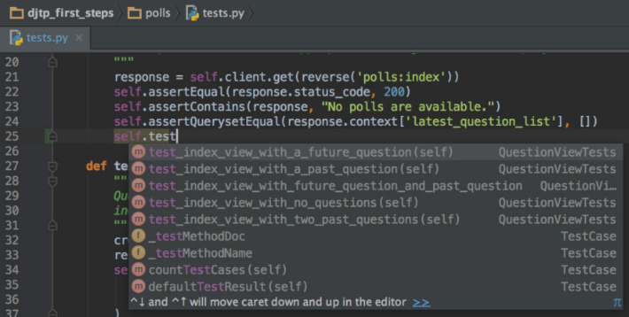

Рис. 2. Подсветка синтаксиса в `PyCharm`

Вернемся к «программе `Есенин.py»`. В строке 4 параметр end =“n”, передающийся фукнции print(), настраивает её таким образом, чтобы она вставляла спец символ перевода строки n, который отвечает за действие в конце выполнения этой функции. Хотя она и так по умолчанию переводит строку на новую, но для наглядности это сообщено вам. Вы можете, например, вставить пробел вместо перевода строки.

```python
print("Захлебнуться бы в этом угаре,", end = " ")
print("Мой последний, единственный друг.")
```

```
Захлебнуться бы в этом угаре, Мой последний, единственный друг.
```

### Переменные

Теперь давайте начнем вводить переменные. Переменные хранят значение, которое можно просмотреть или изменить позже. Создадим программу, использующую переменные. Запустите представленный ниже код и попробуйте разобраться в результатах его работы:

```python
#демонстрация переменных
print("Эта программа представляет собой демонстрацию переменных")
v = 1
print("Сейчас значение v: ", v)
v = v + 1
print("v теперь равно самому себе плюс один, что делает его равным ", v)
v = 51
print("v может хранить любое числовое значение для использования в другом месте.")
print("например, в предложении. v теперь равно ", v)
print("v умножить на 5 равно", v * 5)
print("но само v все еще остается равно", v)
print("чтобы увеличить v в пять раз, нужно набрать v = v * 5")
v = v * 5
print("вот так, теперь v равно", v, "а не ", v / 5)
```

```
Эта программа представляет собой демонстрацию переменных
Сейчас значение v:  1
v теперь равно самому себе плюс один, что делает его равным  2
v может хранить любое числовое значение для использования в другом месте.
например, в предложении. v теперь равно  51
v умножить на 5 равно 255
но само v все еще остается равно 51
чтобы увеличить v в пять раз, нужно набрать v = v * 5
вот так, теперь v равно 255 а не  51.0
```

Обратите внимание, что мы также можем записать `v=v+1` как `v+=1`. Это можно использовать для всех операторов (например, `-=`, `*=`, `/=`). Попробуйте это в приведенном выше коде.

Для названий переменных рекомендуется использовать строчные буквы или «верблюжий регистр». `CamelCase` (с англ. – «ВерблюжийРегистр», также «ГорбатыйРегистр», «СтильВерблюда») – стиль написания составных слов, при котором несколько слов пишутся слитно без пробелов, при этом каждое слово внутри фразы пишется с прописной буквы.

В названии переменных нельзя использовать специальные символы или начинать названия с цифр.

### Строки

Переменные хранят значения для использования их при дальнейшей работе программы. Вы можете изменить их в любой момент. Однако вы можете хранить в переменных не только цифры. Переменные могут содержать, например текст.

Переменная, содержащая текст, называется строкой. Попробуйте эту программу:

```python
#обьявление и определение строковых переменных, сложение строк
word1 = "Добрый"
word2 = "вечер"
word3 = "вам!"
print(word1, word2)
sentence = word1 + " " + word2 + " " + word3
print(sentence)
```

```
Добрый вечер
Добрый вечер вам!
```

Указанные выше переменные содержали текст. Имена переменных также могут быть длиннее одной буквы – здесь у нас были слова `word1`, `word2` и `word3`.

В примере выше продемонстрировано, что строки можно складывать вместе, чтобы получились более длинные слова или предложения. Тем не менее, оператор сложения не добавляет пробелов между словами – поэтому можно вставить строку, содержащую только пробел «” “» (показано в примере).

Попробуйте использовать следующий код и объясните, что он делает:

```python
text = "abcdefghij"
len(text)
```

```
10
```

Представленный выше код выводит количество символов в строке. А теперь попробуйте выполнить это:

```python
print(text[4])
```

```
e
```

Здесь мы хотим напечатать символ, стоящий в позиции 4. Обратите внимание, что первый символ «`a`» находится в позиции 0, потому что индексация в языке программирования `Python` начинается с нуля. Итак, позиция 4 возвращает нам букву «`е`». А теперь попробуйте:

```python
print(text[:4])
print(text[4:])
```

```
abcd
efghij
```

Конструкция `[:4]` выбирает символы с индексами 0, 1, 2, 3, то есть «`abcd`». Используя оператор обрезания «двоеточие» в конструкции `[4:]` мы осуществляем выборку элементов, начинающихся с позиции с индексом 4, и до конца строки, в результате получаем вывод куска исходной строки «`efghij`». По английский обрезка – `slice`, поэтому часто результат обрезки называют «`слайс`».

Мы также можем указать диапазон. Попробуйте это:

```python
print(text[4:8])
```

```
efgh
```

Для диапазонов максимальное значение (индекс 8 из примера выше) не включается в выборку.

Отрицательные индексы означают индексацию справа-налево, а положительные классическую – слева на право.

Попробуем вывести второй символ справа. А затем попробуем выбрать четвертый символ и правее (т.е. сделаем вырезку «начать с 4-го символа справа и вывести все символы от этой позиции до конца строки»).

```python
#text = "abcdefghij"
print(text[-2])
print(text[-4:])
```

```
i
ghij
```

Попробуйте выполнить и понять, что делает этот код:

```python
print(text[::2])
```

```
acegi
```

Данный код вырезает каждый второй элемент. Условно «второй», потому что по факту он вырезает каждый первый по индексу элемент, так как индексация начинается с нуля, а указывать в данной конструкции необходимо тот индекс, до которого нужно выбирать символы, не включая его.

Мы также можем добавить результаты нарезки списка к переменным и вставить их в строки, используя метод `format()` (что такое метод будет рассмотрено на следующем занятии):

```python
nrOfCharacters = len(sentence)
lastWord = sentence[-4:-1]
print("В предложении есть {} символов, а последнее слово: {}".format(nrOfCharacters,lastWord))
```

```
В предложении есть 17 символов, а последнее слово: вам
```

Таким образом, вы можете легко вставлять переменные в места в строках, отмеченные оператором ассоциации «`{}`». Они будут подставлены в том же порядке, что и переменные в методе «`.format()`». Это также можно записать как:

```python
print(f"В предложении {nrOfCharacters} букв и последнее слово: {lastWord}")
```

```
В предложении 17 букв и последнее слово: вам
```

У нас все еще в «памяти» интерпретатора языка `Python` хранится переменная «предложение» (`sentence`). Попробуйте вывести второе слово предложения, используя полученные навыки:

```python
print(sentence)
print(sentence[6:12])
```

```
Добрый вечер вам!
 вечер
```

Помимо нарезки списка есть также другие операции, которые мы можем применить к строкам. Мы можем подсчитать количество вхождений определенного символа в строку:

```python
print(sentence.count('o'))
```

```
0
```

Мы также можем найти положение символа. Ниже представлено два примера с использованием двух разных методов для этого.

```python
print(text.find('e'))
sometext = "Привет, как дела как?"
print(sometext.rfind("как"))
```

```
4
17
```

Метод `rfind()` возвращает последнее появление строки. Итак, в текстовой переменной `sometext` мы дважды употребляем слово «как». Метод `rfind()` возвращает 17, что означает, что последний раз, когда он нашел слово «как», он начинался с позиции 17 (считая с 0).

Есть еще несколько полезных методов для строк, некоторые примеры которых представлены ниже. Запустите приведенный ниже код и проанализируйте результат:

```python
# Переводит строку в верхний регистр
print(sometext.upper())

# Разбивает строку и возвращает ее как элементы списка. Вы узнаете о списках позже
print(sometext.split(","))

# Заменяет строки
print(sometext.replace("?","!"))
```

```
ПРИВЕТ, КАК ДЕЛА КАК?
['Привет', ' как дела как?']
Привет, как дела как!
```

Также есть некоторые специальные символы:

- «`\n`» – переходит на новую строку
- «`\`» – escape-символ (escape – с англ. освобождающий, экранирующий). Вы можете поместить его перед другим символом, который имеет значение в коде и не считается строкой. Как один из примеров применения, экранирование часто используется, чтобы иметь строки, представляющие собой пути к файлу (например, «`C:\\папка\\имя_файла.txt`»). Поскольку «`\`» уже является escape-символом, нам нужно использовать его дважды, чтобы экранировать косую черту в строке (экранировать – означает, что в нашей строке действительно используется символ «слеш», а не спец символ).

Ниже представлено несколько примеров использования специальных символов «`n`» и «`\`». Обратите внимание, что специальных символов существует большее количество, чем два (указанных). Они аналогичны тем, что используются в других языках программирования.

```python
print("Это очень длинное предложение, и я хочу разбить его на две строки.")
print("Это очень длинное предложение \n, и я хочу разбить его на две строки.")
print("Это предложение содержит цитату, и я не хочу, чтобы строка заканчивалась (пока) \"")
```

```
Это очень длинное предложение, и я хочу разбить его на две строки.
Это очень длинное предложение
, и я хочу разбить его на две строки.
Это предложение содержит цитату, и я не хочу, чтобы строка заканчивалась (пока) "
```

### Циклы

Представьте, что вам нужна программа, которая сделает что-то 20 раз. Вы можете скопировать и вставить код 20 раз и получить потенциально более медленную и практически нечитаемую программу. Для решения этой проблемы вы можете «приказать» компьютеру повторять фрагмент кода между точками A и B, пока не выполнится условие, при котором нужно будет остановится. Это называется циклом.

### Цикл «while»

Ниже приведены примеры цикла, называемого циклом `while` (while c англ. – пока). Пока выполняется некоторое условие, то код, располагающийся внутри цикла `while, будет выполнятся.`

```python
a = 0
while a < 10:
    a = a + 1
    print(a)
```

```
1
2
3
4
5
6
7
8
9
10
```

Код, который расположен внутри цикла называется телом цикла. Тело бывает не только у циклов, но и у множества других конструкций языка программирования. Тело и вложенность кода задается при помощи 4 пробелов (или нажатия клавиши tab).

Ниже представлено описание кода на алгоритмическом языке. Алгоритмический язык описывает последовательность работы программы на естественном русском языке:

[output not shown]

Цикл `while` имеет следующий синтаксис:

```
while {условие продолжения цикла}:
{код тела цикла (что делать)}
{тело всегда отделяется tab-ом или 4-мя пробелами}
код здесь не зациклен
потому что он без отступа
```

Теперь проанализируйте результат выполнения представленного ниже кода:

```python
x = 10
while x != 0:
    print(x)
    x = x - 1
    print("мы посчитали х, и теперь он равен", x)
print("И вот цикл закончен.")
```

```
10
мы посчитали х, и теперь он равен 9
9
мы посчитали х, и теперь он равен 8
8
мы посчитали х, и теперь он равен 7
7
мы посчитали х, и теперь он равен 6
6
мы посчитали х, и теперь он равен 5
5
мы посчитали х, и теперь он равен 4
4
мы посчитали х, и теперь он равен 3
3
мы посчитали х, и теперь он равен 2
2
мы посчитали х, и теперь он равен 1
1
мы посчитали х, и теперь он равен 0
И вот цикл закончен.
```

В примере было показано, что «`print(“И вот цикл закончен.”)`», не являющийся элементов тела цикла, выполнился только 1 раз. Цикл выполняет то, что внутри его тела, пока условие выполняется `«x != 0»`, т.е. истинно.

### Логические (или булевы) выражения

В области, отмеченной `{условия продолжения цикла}`, которую мы с вами рассматривали выше, указывается выражение, называемое логическим или булевым. Логическое выражение означает вопрос, на который можно ответить `истина` или `ложь` (`true` и `false` с англ. соответственно). Например, если вы хотите сравнить равенство вашего возраста с возрастом человека, который рядом с вами, вы должны ввести:

```
Мой возраст == возраст человека рядом со мной
```

Для вы создания логических выражений вы можете использовать любые операторы сравнения, которые представлены в таблице ниже (Таблица 3).

Таблица 3. Операторы сравнения

| Оператор | Описание | Пример для а=10, b=20 |
| --- | --- | --- |
| ==, != или <> | Оператор «равно» и два варианта оператора «не равно» соответственно. | (а == b) не верно (а != b) истинно |
| > и < | Оператор «больше» и оператор «меньше» соответственно. | (а > b) не верно (а < b) истинно |
| >= и <= | Оператор «больше или равно» и оператор «меньше или равно» соответственно. | (а >= b) не верно (а <= b) истинно |

Не стоит путать «`=`» и «`==`». Оператор присваивания «`=`» делает то, что находится слева, равным тому, что находится справа. оператор сравнения «`==`» говорит, совпадает ли элемент слева с тем, что находится справа, и возвращает `True` или `False`.

### Условные инструкции

Условные инструкции (выражения)– это когда часть кода запускается только при соблюдении определенных условий. Это похоже на работу цикла `while`, рассмотренную ранее, однако тело условных инструкций выполняются только один раз. Самым распространенным условным выражением в любом языке программирования является оператор `if`. Ниже представлен его синтаксис:

```
if {условия, которые должны быть выполнены}:
    {сделай это}
    {и это}
    {и это}
{но это происходит независимо}
{потому что это без отступа}
```

Рассмотрим несколько примеров на `Python`, представленных ниже:

```python
#Пример 1
y = 1
if y == 1:
    print("y по-прежнему равно 1, я просто проверял")
```

```
y по-прежнему равно 1, я просто проверял
```

```python
#Пример 2
print("Мы покажем четные числа до 20")
n = 1
while n <= 20:
    if n % 2 == 0:
        print(n)
    n = n + 1
print("готово")
```

```
Мы покажем четные числа до 20
2
4
6
8
10
12
14
16
18
20
готово
```

Пример 2 выглядит непростым. Но все, что мы в нем выполняется – это запуск оператора `if` каждый раз, когда выполняется тело цикла `while` (каждый новый так выполнения тела называется итерацией). Математическая операция «`%`» означает остаток от деления, т.е. осуществляется проверка того, что ничего не осталось (остаток равен нулю), если число делится на два – показывая, что оно четное. Если значение переменной `n` четное, то программа выводит его.

### else и elif - операторы “когда это не так”

Есть несколько способов использования оператора `if` для ситуаций, когда ваше логическое выражение оказывается ложным. Это добавление после оператора `if` операторов `else` и `elif`.

Оператор `else`, указанный после `if`, определяет, что делать, если условие в `if` не выполняется. Например, в следующем коде переменная `a` не больше пяти, поэтому то, что указано в `else`, выполняется:

```python
a = 1
if a > 5:
    print("Это не должно выполниться.")
else:
    print("Это должно выполниться.")
```

```
Это должно выполниться.
```

Оператор `elif` – это сокращенный способ указания конструкции `else if`. Когда оператор условие `if` ложно, `elif` будет делать то, что содержится в его теле, если выполняются условия. Например:

```python
z = 4
if z > 70:
    print("Что-то не так")
elif z < 7:
    print("Все ок")
```

```
Все ок
```

Использование оператора `if` вместе с `else` и `elif` выглядит следующим образом:

```
if {#условия}:
    {#выполнить этот код}
elif {#условия}:
    {run this code}
elif {#условия}:
    {#выполнить этот код}
else:
    {#выполнить этот код}
# У вас может быть столько или меньше операторов elif, сколько вам нужно
# Но у вас может быть не более одного оператора else и только после всех остальных if и elifs.
```

Один из наиболее важных моментов, который следует помнить – это то, что вы должны иметь двоеточие в конце каждой строки с `if, elif, else` или `while` в нем. Вы условиях вы так же можете указывать составные условия, созданные при помощи логических операторов «`&`» или «`|`» («и» и «или» соответственно):

```python
if (2>0) & (3>0):
    print("…")
```

```
…
```

### Отступы

Вложенность строк кода в `Python`, как уже было сказано, определяется при помощи 4 пробелов перед каждой вложенной строкой кода. При этом строки кода разделяются между собой переносом строчки на новую (т.е., например, вы не можете напрямую написать несколько `print()` в одной строчке, и например, разделить их запятыми).

Уровней вложенности кода может быть много. Ниже представлен пример, представляющий собой объединение рассмотренных ранее примеров.

```python
a = 10
while a > 0:
    print(a)
    if a > 5:
        print("Большое число!")
    elif a % 2 != 0:
        print("Это нечетное число")
        print("И не больше пяти.")
    else:
        print("это число не больше 5")
        print("и не является нечетным")
    a = a - 1
    print("мы просто сделали на единицу меньше, чем было!")
    print ("и если a не больше 0, мы выполним цикл снова.")
print ("ну, похоже, что 'a' теперь не больше 0!")
print ("цикл окончен, и без дальнейших действий, и эта программа тоже!")
```

```
10
Большое число!
мы просто сделали на единицу меньше, чем было!
и если a не больше 0, мы выполним цикл снова.
9
Большое число!
мы просто сделали на единицу меньше, чем было!
и если a не больше 0, мы выполним цикл снова.
8
Большое число!
мы просто сделали на единицу меньше, чем было!
и если a не больше 0, мы выполним цикл снова.
7
Большое число!
мы просто сделали на единицу меньше, чем было!
и если a не больше 0, мы выполним цикл снова.
6
Большое число!
мы просто сделали на единицу меньше, чем было!
и если a не больше 0, мы выполним цикл снова.
5
Это нечетное число
И не больше пяти.
мы просто сделали на единицу меньше, чем было!
и если a не больше 0, мы выполним цикл снова.
4
это число не больше 5
и не является нечетным
мы просто сделали на единицу меньше, чем было!
и если a не больше 0, мы выполним цикл снова.
3
Это нечетное число
И не больше пяти.
мы просто сделали на единицу меньше, чем было!
и если a не больше 0, мы выполним цикл снова.
2
это число не больше 5
и не является нечетным
мы просто сделали на единицу меньше, чем было!
и если a не больше 0, мы выполним цикл снова.
1
Это нечетное число
И не больше пяти.
мы просто сделали на единицу меньше, чем было!
и если a не больше 0, мы выполним цикл снова.
ну, похоже, что 'a' теперь не больше 0!
цикл окончен, и без дальнейших действий, и эта программа тоже!
```

Обратите внимание на три уровня отступов:

- Каждая строка первого уровня начинается без пробелов. Это основная программа, и она всегда будет выполняться.
- Каждая строка на втором уровне начинается с четырех пробелов. Когда есть `if` или цикл на первом уровне, все на втором уровне после этого будет зациклено, пока новая строка снова не начнется на первом уровне.
- Каждая строка третьего уровня начинается с восьми пробелов. Когда есть `if` или цикл на втором уровне, все на третьем уровне после этого будет зациклено, пока новая строка снова не начнется на втором уровне.
- Это продолжается бесконечно, пока у человека, пишущего программу, сохраняется понимание того, что он пишет.

В других языках программирования вложенность определяется иначе, например в `С++` для определения вложенности используются фигурные скобки и точки запятой вместо 4 пробелов и переноса строк соответственно.

### Функции

Функции – это небольшие структуры кода, которые выполняют определенную задачу, когда вы запускаете их.

После того, как вы создали функцию, вы можете использовать ее в любое время и в любом месте. Это экономит ваше время и усилия, связанные с необходимостью указывать один и тот же набор кода в разных местах. При этом, если вам потребуется поменять код функции, то сделать это нужно будет только в одном месте  – там, где мы его создавали, а не во всех местах, в которых –просто использовали.

`Python` имеет множество готовых функций, которые вы можете использовать, просто «вызывая» их. Вызов функции (именно так называется запуск функции на выполнение) подразумевает, что вы вводите имя функции, выполняется вложенный в нее код, а затем она на месте своего имени возвращает значение (как переменная). Ниже представлен пример синтаксиса вызова функции:  
имя_функции (параметры)

Имя функции определяет, какую функцию вы хотите использовать. Например, функция `raw_input()` (с англ. – сырой ввод) может использоваться для решения задачи, имя которой и несет. Например, обрабатывать «сырой ввод» значений с клавиатуры.

Параметры – это значения, которые вы передаете функции, чтобы сообщить ей, что она должна делать и как это делать. Например, если функция создается для умножения любого требуемого числа на пять, то в параметрах указывается, какое число её следует умножить на пять. Введите число 70 в параметры, тогда функция выполнит 70 x 5 и вернет результат данного действия.

### Параметры и возвращаемые значения - взаимодействие с функциями

Теперь мы знаем, что придуманная и потенциально написанная нами пользовательская функция может умножать число на пять, но что она для должна «показать» пользователю после своего выполнения? Результат умножения, который является и называется возвращаемым значением функции.

Говоря упрощённо, когда интерпретатор выполняет функцию, он «видит» не имя функции, а результат того, что функция сделала, т.е. её возвращаемое значение. Переменные делают то же самое – «компьютер не видит имени переменной», он видит значение, которое содержит переменная.

Назовем функцию, которая умножает любое число на пять, именем «`multiply()»`. При вызове функции (так, как уже было сказано, называется её запуск на выполнение) вы помещаете в скобки число (называется параметром), которое хотите умножить. Итак, если вы бы набрали это[2]:

[2] ☝🙂 Не вводите этот код – `multiply()` не является стандартной функцией, встроенной в `Python`. Это пользовательская функция, которую мы создадим позже.:

```
a = multiply (70)
```

Интерпретатор в действительности «увидит» это:

```
а = 350
```

Функция запустилась, а затем вернула число в основную программу в зависимости от того, какие параметры ей были заданы (в данном случае у нас был только один параметр).

Теперь давайте попробуем это с реальной функцией и посмотрим, что она делает. Для примера, в `Python` существует стандартная функция c названием «`input»,` которая «просит» пользователя что-то ввести (на языке программистов – ожидает пользовательского ввода). Затем он превращает введенное значение в строку текста. Посмотрите на следующий код и результат его выполнения:

```python
# эта строка делает 'a' равным тому, что вы вводите
a = input("Введите что-нибудь, и это будет повторяться на экране:")
# эта строка печатает, сколько значение 'a'
print(a)
```

```
1
```

Скажем, в приведенной выше программе вы бы набрали текст «`hello»`, когда она попросила вас ввести что-то. На компьютере эта программа будет выглядеть так:

```python
a = "hello"
print("hello")
```

```
hello
```

Помните, что переменная – это сохраненное значение. Для компьютера переменная `a` не выглядит как `a` – она выглядит как значение, которое хранится внутри нее. Функции аналогичны – основной программе (то есть программе, в которой выполняется функция) они выглядят как значение того, что они дают в ответ на выполнение.

Функция `input()`, сперва выводит текстовое сообщение, которое вы ей передали в качестве параметра, а затем считывает то, что введет пользователь, и после того, как он нажмет клавишу `enter` – вернет ту строку, которую и вводил пользователь.

### Лямбда функции

Лямбда-выражение позволяет создавать анонимные функции, или, говоря упрощенно – создавать одной маленькой строчкой кода полноценную функцию, у которой не будет имени и использоваться она будет сразу и только там, где вы её написали. Ниже представлено и прокомментировано несколько примеров использования лямбда функций. В целом, никаких существенных отличий от обычных функций нет, и лямбда функции бывают удобными в силу своей краткости.

Лямбда-функции ограничены одним выражением. Это означает, что лямбда-функция не может использовать никакие операторы, даже оператор `return`.

```python
#1ый вариант.Именованная лямбда функция
check_price = lambda price: price>= 2
print (check_price(2))
#2ый вариант. Неименованная лямбда функция
print ((lambda price: price>= 2) (2))
#несколько параметров. Проверка, что цена*колличество не больше 9
print ((lambda price, quantity: price*quantity <= 9) (2, 10))
```

```
True
True
False
```

### Программа «калькулятор»

Напишем другую программу, которая будет выступать в роли калькулятора. На этот раз она будет выполнять что-то более масштабное, чем то, что мы делали раньше. Появится меню, в котором компьютер «спросит» пользователя, какую операцию он хочет выполнить: сложить, вычесть, разделить или перемножить два числа. Единственная проблема – функция `input()` возвращает то, что вы вводите в виде строки – нам нужна цифра 1, а не буква 1 (в `Python` есть разница, потому что переменные обладают типом).

К счастью, в `Python` есть встроенная функция `eval()`, которая выполняет любой `Python` код, который вы ей передадите. Например, если передадите текст `‘1+1’`, то она вернет вам результат равный 2. Это сработает, потому что данный текст тоже является кодом, несмотря на то, что в нем нет переменных, а есть только два числа и математическая операция сложения.

Используя `eval()` мы можем избежать сложностей с ручным разбором строки на отдельные значения и математические операторы. Если вы введете число 1, то результат будет следующий:

```python
# в этой строке «а» становится равным введенному вами значению. Она не принимает строки
a = eval(input("Введите что-нибудь, и это будет повторено на экране: "))
# эта строка печатает, чему равно 'a'
print(a)
```

```
1
```

Теперь давайте спроектируем этот калькулятор более сложным. Например, мы хотим, чтобы нам возвращалось меню каждый раз, когда вы заканчиваете сложение, вычитание и т. д. Другими словами, используем цикл, определяющий должна ли программа работать дальше, или калькулятор нам больше не нужен. Мы хотим, чтобы в меню была опция «если вы введете это число», то осуществить выход из калькулятора.

Давайте сначала напишем модернизированную версию калькулятора на алгоритмическом языке:

```
НАЧАТЬ ПРОГРАММУ
вывести приветственное сообщение

    # Распечатайте, какие у вас есть варианты
     распечатать Вариант 1 - сложить
     печать Вариант 2 - вычесть
     печать Вариант 3 - умножить
     печать Вариант 4 - разделить
     вариант печати 5 - выйти из программы

     спросить, какой вариант ты хочешь
     если это вариант 1:
         спроси первое число
         спроси второе число
         сложите их вместе
         распечатать результат на экране
     если это вариант 2:
         спроси первое число
         спроси второе число
         вычесть одно из другого
         распечатать результат на экране
     если это вариант 3:
         спроси первое число
         спроси второе число
         умножить!
         распечатать результат на экране
     если это вариант 4:
         спроси первое число
         спроси второе число
         разделить одно на другое
         распечатать результат на экране
     если это вариант 5:
         скажите циклу прекратить цикл
Распечатать на экране прощальное сообщение
КОНЕЦ ПРОГРАММЫ
```

Реализуем данный псевдокод при помощи `Python`:

```python
# программа-калькулятор

# эта переменная сообщает циклу, должен он зацикливаться или нет.
#1 означает цикл. Все остальное означает «не зацикливаться».
loop = 1

# эта переменная содержит выбор пользователя в меню:
choice = 0

while loop == 1:
    #print what options you have
    print("Добро пожаловать в программу calculator.py")
    print("Доступны следующие функции:")
    print(" ")
    print("1. Сложение")
    print("2. Вычитание")
    print("3. Умножение")
    print("4. Деление")
    print("5. Выход")
    print(" ")

    choice = eval(input("Осуществите выбор функции: "))
    if choice == 1:
        add1 = eval(input("Прибавить: "))
        add2 = eval(input("к: "))
        print(add1, "+", add2, "=", add1 + add2)
    elif choice == 2:
        sub2 = eval(input("Вычесть: "))
        sub1 = eval(input("из: "))
        print(sub1, "-", sub2, "=", sub1 - sub2)
    elif choice == 3:
        mul1 = eval(input("Умножить: "))
        mul2 = eval(input("на: "))
        print(mul1, "*", mul2, "=", mul1 * mul2)
    elif choice == 4:
        div1 = eval(input("Поделить это: "))
        div2 = eval(input("на: "))
        print(div1, "/", div2, "=", div1 / div2)
    elif choice == 5:
        loop = 0
print("Спасибо вам за использование программы calculator.py!")
```

```
Добро пожаловать в программу calculator.py
Доступны следующие функции:

1. Сложение
2. Вычитание
3. Умножение
4. Деление
5. Выход
```

```
1 + 1 = 2
Добро пожаловать в программу calculator.py
Доступны следующие функции:

1. Сложение
2. Вычитание
3. Умножение
4. Деление
5. Выход
```

```
Спасибо вам за использование программы calculator.py!
```

Поэкспериментируйте с этим – попробуйте все варианты, вводя целые числа (числа без десятичной точки) и числа с добавлением после десятичной точки (известные в программировании как числа с плавающей запятой). Попробуйте ввести текст и посмотрите, как программа перестает работать (с этим можно справиться, используя обработку ошибок, о которой мы поговорим позже).

### Пользовательские функции (свои собственные функции)

Ранее мы рассмотрели использование некоторых встроенных в `Python` функций. Если вы хотите написать свои собственные функции, то необходимо использовать оператор[3] `def`.

[3] ☝🙂 Понятие «оператор» – это то, что говорит интерпретатору Python, что делать, например, оператор «+» говорит Python добавить что-то, оператор if говорит Python что-то делать, если условия выполнены.

Синтаксис использования оператора `def` следующий:

```
def function_name(параметр_1,параметр_2):
    {код функции}
    {больше кода}
    {больше кода}
    return {возвращаемое значение функции}
{этого кода нет в функции}
{потому что это без отступа}
# не забудьте поставить двоеточие ":" в конце
# строки, начинающейся с def
```

`где function_name` – это имя функции. Вы пишете код, который находится в функции под этой строкой, с отступом в 4 пробела. Мы ещё поговорим о передаваемых (и принимаемых) функции (и функцией) параметрах `параметр_1` и `параметр_2` позже, а пока представьте, что между скобками нет ничего.

Функции выполняются полностью независимо от основной программы. Ранее было сказано, что, когда интерпретатор переходит к функции, он «видит» не функцию, а значение, которое функция возвращает. Ниже представлена сокращенная цитата:

«Для компьютера переменная `a` выглядит как значение, которое хранится внутри нее. Функции аналогичны – они выглядят как значение того, что они дают в ответ на своё выполнение.»

Функция похожа на миниатюрную программу, которой передаются некоторые параметры – затем она запускается сама, а далее возвращает значение. Ваша основная программа «видит» только возвращаемое значение. Если бы эта функция в конце своего тела имела бы инструкцию возвращаемого значения `return` (c англ. return – вернуть):

```
return 'hello'
```

то тогда вся интерпретатор в вашей программе «увидит» строку «`hello`», на том месте, где было имя функции.

Поскольку это отдельная программа, функция не видит[4] никаких переменных, которые есть в вашей основной программе, а ваша основная программа не видит никаких переменных, которые находятся в функции. Например, вот функция, которая выводит на экран слово «привет», а затем возвращает число «1234» в основную программу:

[4] ☝🙂 Ранее слово «видит» использовалось в кавычках, т.к. не использовалось в качестве термина. Здесь же слово «видит» является термином, потому что в программировании есть такое понятие, как «зона видимости». В данном контексте, функция действительно «не видит переменных основной программы» (цитата), потому что они находятся вне её зоны видимости. Она видит только переданные ей в параметрах переменные, либо свои внутренние переменные, либо переменные обьявленные внутри нее, но с флагом `global`.

```python
# Ниже приведено определение пользовательской функции
def hello():
    print("Привет")
    return 1234
# А вот вызов (использование) данной пользовательской функции
print(hello())
```

```
Привет
1234
```

При выполнении «`def hello()»` была создана (объявлена) функция с именем «hello». Когда была запущена строка «`print(hello())»`, была выполнена функция `hello()` (и код внутри нее был запущен).

### Передача параметров функциям

Вспомните, как мы определяли функции:

```
def имя_функции (параметр_1, параметр_2):
     {это код функции}
     {дополнительный код}
     {дополнительный код}
     return {значение (например, текст или число), чтобы вернуться в основную программу}
```

Где `параметр_1` и `параметр_2` (в скобках), вы помещаете имена переменных, в которые вы хотите поместить параметры. Введите столько параметров, сколько вам нужно, разделяя их запятыми.

Когда вы запускаете функцию, первое значение, которое вы помещаете в круглые скобки, переходит в переменную, где находится `параметр_1`. Второй (после первой запятой) параметр перейдет к переменной, в которой находится `параметр_2`. Это происходит для любого количества параметров функции (от нуля и больше). Например:

```python
def funnyfunction(first_word,second_word,third_word):
    print("Слово: " + first_word + second_word + third_word)
    return first_word + second_word + third_word
```

Добавьте в приведенный выше код вызов функции.

### Модернизация программы «калькулятор»

Вернемся к программе «калькулятор». Давайте перепишем её с использованием функций, чтобы она была более читаемой. Сначала мы определим все функции, которые мы собираемся использовать, с помощью оператора `def`. Затем у нас будет основная программа, в которой весь этот беспорядочный код будет заменен функциями.

```python
# программа-калькулятор
# Здесь мы определим наши функции
# это печатает главное меню и предлагает выбор
def menu():
    #печать списка доступных функций
    print("Добро пожаловать в программу calculator.py")
    print("Доступны следующие функции:")
    print(" ")
    print("1. Сложение")
    print("2. Вычитание")
    print("3. Умножение")
    print("4. Деление")
    print("5. Выход")
    print(" ")
    return eval(input("Осуществите выбор функции: "))

# функция сложения
def add(a,b):
    print(a, "+", b, "=", a + b)

#функция вычитания
def sub(a,b):
    print(b, "-", a, "=", b - a)

#функция умножения
def mul(a,b):
    print(a, "*", b, "=", a * b)

# функция деления
def div(a,b):
    print(a, "/", b, "=", a / b)

loop = 1
choice = 0
while loop == 1:
    choice = menu()
    if choice == 1:
        add(eval(input("Прибавить: ")),eval(input("к: ")))
    elif choice == 2:
        sub(eval(input("Вычесть: ")),eval(input("из: ")))
    elif choice == 3:
        mul(eval(input("Умножить: ")),eval(input("на: ")))
    elif choice == 4:
        div(eval(input("Разделить: ")),eval(input("на: ")))
    elif choice == 5:
        loop = 0

print("Спасибо за использование программы calculator.py!")
```

```
Добро пожаловать в программу calculator.py
Доступны следующие функции:

1. Сложение
2. Вычитание
3. Умножение
4. Деление
5. Выход
```

```
1 + 1 = 2
Добро пожаловать в программу calculator.py
Доступны следующие функции:

1. Сложение
2. Вычитание
3. Умножение
4. Деление
5. Выход
```

```
Спасибо за использование программы calculator.py!
```

В исходной программе было 34 строки кода. В новом коде фактически 35 строк кода. Он немного длиннее, но, если смотреть на него с точки зрения опытного программиста, на самом деле он проще и более читаем.

Вы определили все свои функции вверху файла программы. На самом деле это не часть вашей основной программы – это просто множество маленьких программ, которые вы вызовете позже[4]. Вы можете повторно использовать их в другой программе, не вынося их из этого файла. Это будет рассмотрено на следующем занятии.

Если вы посмотрите на основную часть программы (между строками «`loop=1»` и «`print(«Спасибо за …»)»)`, то это всего 15 строк кода. Это означает, что, если бы вы захотели написать эту программу другим способом, вам нужно было бы написать всего около 15 строк, в отличие от 34 строк, которые вам обычно приходилось бы писать без функций.

### Хитрые способы передачи параметров

Рассмотрим, что означают следующие строки программы «калькулятор»:

```
add(eval(input(“Прибавить:”)),eval(input(“к:”)))
```

```
add (2,30)
```

Как более простой пример, в качестве параметров для функции сложения вы можете использовать обычные переменные вместо функций. Например.

```
value1= 2
value2 = 30
add (value1, value2)
```

После вызова функции, запустится её код, т.е. сложит полученные параметры 2 и 30, а затем распечатает результат. В функции сложения нет инструкции `return` – т.е. она (эта функция) ничего не возвращает в основную программу. Она просто складывает два числа и сразу самостоятельно выводит их на экран, а основная программа ничего из этого не видит.

Функция, в которую вы передаете параметры, не может изменять исходные параметры. Единственное, что видит функция, – это значения, которые ей передаются в качестве параметров. Эти значения помещаются в переменные, которые упоминаются при определении `add()` (строка «`def add (a, b)»`). Затем функция использует эти параметры для выполнения своей работы.

Подытожим вышесказанное про функции:

- Единственное, что функции основной программы видят – это параметры, которые им передаются.
- Единственное, что основная программа видит из функций, – это их возвращаемое значение, которое функция возвращает.

## Контрольные задания и вопросы

1. Что делает функция `print()` и как с её помощью выводить значение переменной? Опишите значение параметра `end`. Как вывести две строки одной строчкой (сложить строки)?
2. Опишите существующие типы переменных в `Python` (строки, числа и др.).
3. Как обрезать строки?
4. Что такое цикл `while` – объясните на примере.
5. Сделайте собственную функцию, которая бы вычисляла сумму двух чисел с плавающей и проверяла больше ли она числа Пи. Если больше, то сделать вывод текста «больше…» и наоборот.